# Exploratory Data Analysis

Author

Florencia Irene

# Libraries

```r
pacman::p_load(readxl,tidyverse, lubridate, sf, rnaturalearth, rnaturalearthdata, countrycode, scales, RColorBrewer)
```

# Data Pre-Processing

Let’s load the data first

```r
retail = read_excel('Online Retail.xlsx')
head(retail)
```

```
# A tibble: 6 × 8
  InvoiceNo StockCode Description         Quantity InvoiceDate         UnitPrice
  <chr>     <chr>     <chr>                  <dbl> <dttm>                  <dbl>
1 536365    85123A    WHITE HANGING HEAR…        6 2010-12-01 08:26:00      2.55
2 536365    71053     WHITE METAL LANTERN        6 2010-12-01 08:26:00      3.39
3 536365    84406B    CREAM CUPID HEARTS…        8 2010-12-01 08:26:00      2.75
4 536365    84029G    KNITTED UNION FLAG…        6 2010-12-01 08:26:00      3.39
5 536365    84029E    RED WOOLLY HOTTIE …        6 2010-12-01 08:26:00      3.39
6 536365    22752     SET 7 BABUSHKA NES…        2 2010-12-01 08:26:00      7.65
# ℹ 2 more variables: CustomerID <dbl>, Country <chr>
```

There are around 25% missing data. Rule of thumb is 5% missing data, so with 25% rate this is a little alarming. Let’s try to understand the missing values!

```r
# count total missing values
sum(is.na(retail))
```

```
[1] 136534
```

Here I am trying to see what variables have missing values, which turned out are CustomerID and Description.

```r
# count missing values in each columns
colSums(is.na(retail))
```

```
  InvoiceNo   StockCode Description    Quantity InvoiceDate   UnitPrice
          0           0        1454           0           0           0
 CustomerID     Country
     135080           0
```

Interestingly, all the missing values in CustomerID have invoice starting with “5”

```r
retail %>%
  filter(if_any(CustomerID, is.na))
```

```
# A tibble: 135,080 × 8
   InvoiceNo StockCode Description        Quantity InvoiceDate         UnitPrice
   <chr>     <chr>     <chr>                 <dbl> <dttm>                  <dbl>
 1 536414    22139     <NA>                     56 2010-12-01 11:52:00      0
 2 536544    21773     DECORATIVE ROSE B…        1 2010-12-01 14:32:00      2.51
 3 536544    21774     DECORATIVE CATS B…        2 2010-12-01 14:32:00      2.51
 4 536544    21786     POLKADOT RAIN HAT         4 2010-12-01 14:32:00      0.85
 5 536544    21787     RAIN PONCHO RETRO…        2 2010-12-01 14:32:00      1.66
 6 536544    21790     VINTAGE SNAP CARDS        9 2010-12-01 14:32:00      1.66
 7 536544    21791     VINTAGE HEADS AND…        2 2010-12-01 14:32:00      2.51
 8 536544    21801     CHRISTMAS TREE DE…       10 2010-12-01 14:32:00      0.43
 9 536544    21802     CHRISTMAS TREE HE…        9 2010-12-01 14:32:00      0.43
10 536544    21803     CHRISTMAS TREE ST…       11 2010-12-01 14:32:00      0.43
# ℹ 135,070 more rows
# ℹ 2 more variables: CustomerID <dbl>, Country <chr>
```

The missing customerID mostly are from UK and EIRE.

```r
retail %>%
  filter(if_any(CustomerID, is.na)) %>%
  group_by(Country) %>%
  count() %>%
  arrange(desc(n))
```

```
# A tibble: 9 × 2
# Groups:   Country [9]
  Country             n
  <chr>           <int>
1 United Kingdom 133600
2 EIRE              711
3 Hong Kong         288
4 Unspecified       202
5 Switzerland       125
6 France             66
7 Israel             47
8 Portugal           39
9 Bahrain             2
```

Despite the high rate of missing values, the primary focus of this project is on understanding customer segments rather than achieving precise predictions. Therefore, I will remove the missing data. While this might impact the precision of the analysis, it should not significantly affect the overall insights or strategic value of the segmentation.

```r
df<- retail %>%
  drop_na(CustomerID)
```

For the descriptions’ missing values, I will handle it by removing it for later analysis, as it doesn’t really matter because the data set have Stock Code which represents the code for each unique item.

Now, let’s look at the summary of values for each variable. In the summary below, we can see that Quantity and UnitPrice have negative values. For Quantity, negative values make sense as they could represent returned stocks. Negative values for UnitPrice might indicate discounts.

```r
summary(retail)
```

```
  InvoiceNo          StockCode         Description           Quantity
 Length:541909      Length:541909      Length:541909      Min.   :-80995.00
 Class :character   Class :character   Class :character   1st Qu.:     1.00
 Mode  :character   Mode  :character   Mode  :character   Median :     3.00
                                                          Mean   :     9.55
                                                          3rd Qu.:    10.00
                                                          Max.   : 80995.00

  InvoiceDate                       UnitPrice           CustomerID
 Min.   :2010-12-01 08:26:00.00   Min.   :-11062.06   Min.   :12346
 1st Qu.:2011-03-28 11:34:00.00   1st Qu.:     1.25   1st Qu.:13953
 Median :2011-07-19 17:17:00.00   Median :     2.08   Median :15152
 Mean   :2011-07-04 13:34:57.16   Mean   :     4.61   Mean   :15288
 3rd Qu.:2011-10-19 11:27:00.00   3rd Qu.:     4.13   3rd Qu.:16791
 Max.   :2011-12-09 12:50:00.00   Max.   : 38970.00   Max.   :18287
                                                      NA's   :135080
   Country
 Length:541909
 Class :character
 Mode  :character
```

Based on the summary below, Regenct Cakestand 3 tier, manual, postage are highly returned item(I assumed).

```r
df %>%
  filter(Quantity <= 0) %>%
  group_by(Description) %>%
  count() %>%
  arrange(desc(n))
```

```
# A tibble: 1,944 × 2
# Groups:   Description [1,944]
   Description                            n
   <chr>                              <int>
 1 REGENCY CAKESTAND 3 TIER             181
 2 Manual                               175
 3 POSTAGE                               97
 4 JAM MAKING SET WITH JARS              86
 5 Discount                              77
 6 SET OF 3 CAKE TINS PANTRY DESIGN      73
 7 STRAWBERRY CERAMIC TRINKET BOX        55
 8 ROSES REGENCY TEACUP AND SAUCER       53
 9 RECIPE BOX PANTRY YELLOW DESIGN       47
10 WOOD 2 DRAWER CABINET WHITE FINISH    45
# ℹ 1,934 more rows
```

Furthermore, I will remove this negative quantity and unitprice from the dataset as my main focus on this project is to analyze pattern in purchases.

Let’s remove both of them

```r
df <- df %>%
  filter(Quantity > 0)

df <- df %>%
  filter(UnitPrice > 0)

#write.csv(df, file = "edited_df.csv", row.names = FALSE)
```

Now for the Invoice date, we will extract the date only and removes the time.

```r
df <- df %>%
  mutate(Date = paste(year(InvoiceDate), "-", month(InvoiceDate),"-" , day(InvoiceDate) ,sep = "")) %>%
  select(-InvoiceDate)
```

Now let’s do data visualization!

# Geogspatial Distribution of Total Purchases

First I am going to make a new column: “Amount”, which is the total amount of purchases for each observation and I will calculate total purchases by country.

```r
#calculating country purchases (total amount of purchases)
country <- df %>%
  mutate(Amount = Quantity*UnitPrice)

#sum up the purchases by each country
country2 <- country %>%
  group_by(Country) %>%
  summarise(TotalAmount = sum(Amount)) %>%
  arrange(desc(TotalAmount))

country2
```

```
# A tibble: 37 × 2
   Country        TotalAmount
   <chr>                <dbl>
 1 United Kingdom    7308392.
 2 Netherlands        285446.
 3 EIRE               265546.
 4 Germany            228867.
 5 France             209024.
 6 Australia          138521.
 7 Spain               61577.
 8 Switzerland         56444.
 9 Belgium             41196.
10 Sweden              38378.
# ℹ 27 more rows
```

I will remove unspecified, as it is not helpful for visualization.

I decided to use a log transformation for the total purchases visualization because the data is highly skewed. Without this transformation, color differences would be less noticeable. In the visualization below, hot colors indicate regions with higher total purchases.

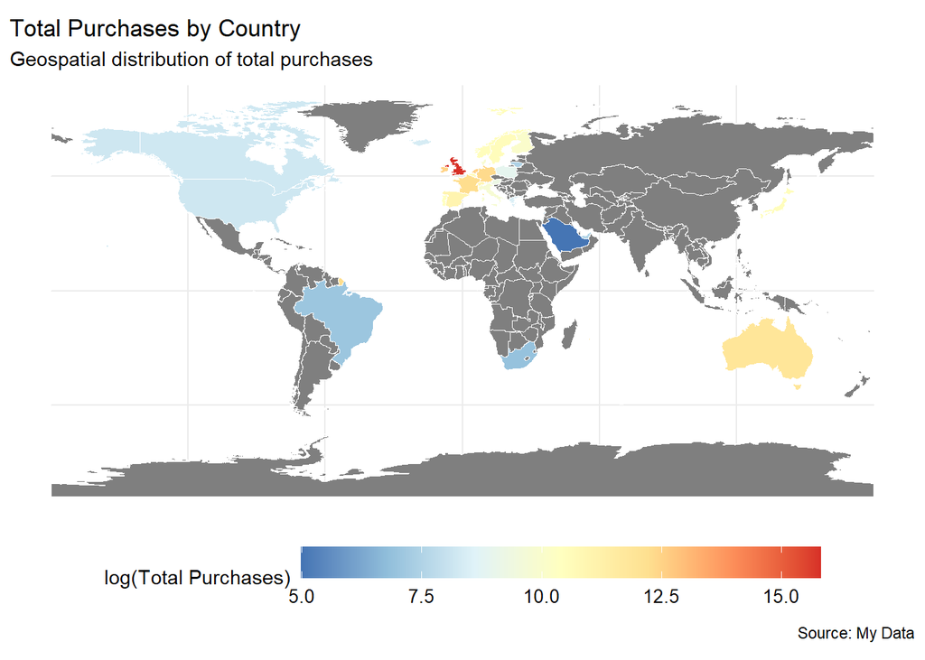

```r
#removing unspecified
country2 <- country2 %>%
  filter(Country != "Unspecified")

#load world map data
world <- ne_countries(scale = "medium", returnclass =  "sf")

#country name corrections
corrections <- c(
  "EIRE" = "Ireland",
  "Channel Islands" = "United Kingdom",
  "USA" = "United States of America",
  "RSA" = "South Africa"
)

#applying corrections
country2 <- country2 %>%
  mutate(Country = recode(Country, !!!corrections)) %>%
  group_by(Country) %>%
  summarise(TotalPurchases = sum(TotalAmount)) %>%
  arrange(desc(TotalPurchases))

#merge with  the dataset
world_data <- world %>%
  left_join(country2, by = c("name" = "Country"))

ggplot(data = world_data) +
  geom_sf(aes(fill = log1p(TotalPurchases)), color = "white")+
  scale_fill_distiller(palette = "RdYlBu", name = "log(Total Purchases)", labels = label_comma()) +
  theme_minimal() +
  labs(title = "Total Purchases by Country",
       subtitle = "Geospatial distribution of total purchases",
       caption = "Source: My Data") +
  theme(legend.position = "bottom",
        legend.key.width = unit(2, "cm"),
        legend.text = element_text(size = 10))
```

# Purchases percentage by country and volume

I also want to visualize the total purchase percentage alongside the order volume. The size of each point represents the volume of orders. I applied a log transformation to the total purchases for the same reason as before—due to skewness. Without this transformation, the distance between the UK and other countries on the graph would be exaggerated.

From the visualization below, we can see that the UK accounts for the highest percentage of total purchases and has the highest order volume, followed by the Netherlands, Ireland, and Germany.

```r
#calculate total purchases
country1 <- df %>%
  mutate(Amount = Quantity*UnitPrice) %>%
  group_by(Country) %>%
  summarise(n = n(),
            TotalPurchases = sum(Amount)) %>%
  mutate(purchase_pct = (TotalPurchases/sum(TotalPurchases))*100) %>%
  arrange((purchase_pct))

country1
```

```
# A tibble: 37 × 4
   Country                  n TotalPurchases purchase_pct
   <chr>                <int>          <dbl>        <dbl>
 1 Saudi Arabia             9           146.      0.00164
 2 Bahrain                 17           548.      0.00615
 3 Czech Republic          25           827.      0.00928
 4 RSA                     57          1002.      0.0112
 5 Brazil                  32          1144.      0.0128
 6 European Community      60          1300.      0.0146
 7 Lithuania               35          1661.      0.0186
 8 Lebanon                 45          1694.      0.0190
 9 United Arab Emirates    68          1902.      0.0213
10 Unspecified            244          2667.      0.0299
# ℹ 27 more rows
```

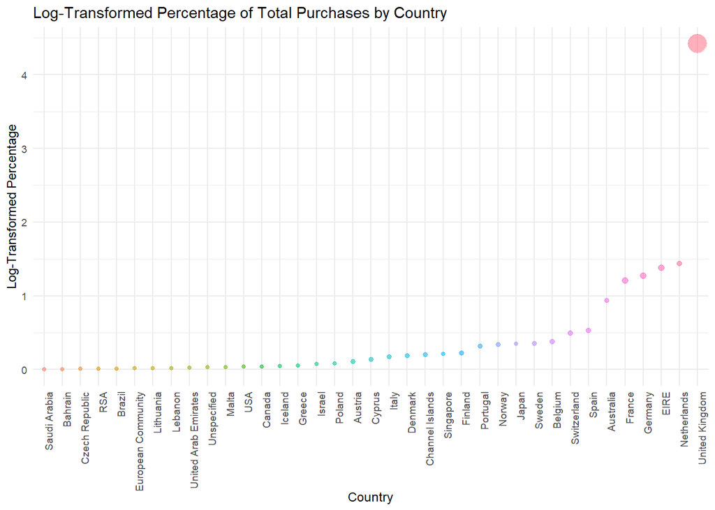

```r
country1 %>%
  ggplot(aes(x = reorder(Country,log1p(purchase_pct)), y = log1p(purchase_pct))) +
  geom_point(aes(size = n, colour = factor(purchase_pct), alpha = 0.8))+
  theme_minimal(base_size =  9)+
  theme(axis.text.x = element_text(angle = 90, hjust = 1) , legend.position="none")+
  labs(x="Country",
       y = "Log-Transformed Percentage",
       title = "Log-Transformed Percentage of Total Purchases by Country")
```

# Most Popular Item Sold

I also want to visualize the top 10 Item sold. So here’s the graph below:

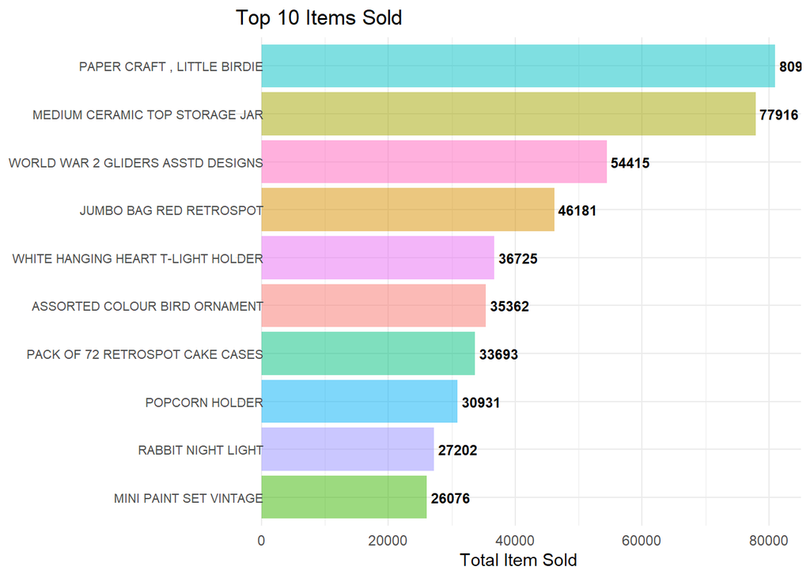

```r
#summarizing top 10 sold items
item <- df %>%
  group_by(Description) %>%
  summarise(item_sold = sum(Quantity)) %>%
  arrange(desc(item_sold)) %>%
  slice_head(n = 10)

#visualization
item %>%
  ggplot(aes(x = item_sold, y = reorder(Description, item_sold), fill = Description))+
  geom_col(alpha = 0.5)+
  geom_text(aes(label = item_sold),
            size = 3,
            hjust = -0.1,
            fontface = "bold")+
  theme_minimal()+
  theme(axis.title.y = element_blank(),
        axis.text.y = element_text(size = 8, margin = margin(r = -20)),
        legend.position = "none")+
  labs(x = "Total Item Sold", title = "Top 10 Items Sold")
```

# Sales Trends

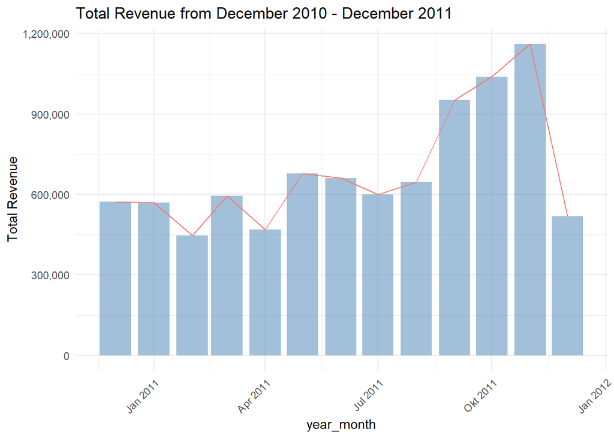

```r
#Convert the date variable to POSIXct type
df_date <- df %>%
  mutate(year_month = as.POSIXct(paste0(year(Date), "-", month(Date), "-01")))

df_date %>%
  mutate(Amount = Quantity*UnitPrice) %>%
  group_by(year_month) %>%
  summarise(total_revenue = sum(Amount)) %>%
  ggplot(aes(x = year_month, y = total_revenue)) +
  geom_col(fill = "steelblue", alpha = 0.5)+
  geom_line(aes(group = 1, color = "Orange"))+
  scale_y_continuous(labels = label_number(scale = 1, big.mark = ","))+
  theme_minimal()+
  theme(axis.text.x = element_text(angle = 45, hjust = 1),
        legend.position = "none")+
  labs(y = "Total Revenue",
       title = "Total Revenue from December 2010 - December 2011")
```